# ME323 - Introdução aos Modelos Probabilísticos

## Fundamentos de Inferência

## Introdução

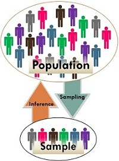

> Um dos principais objetivos da Estatística é tirar conclusões a partir dos dados.

> Dados em geral consistem de uma amostra de elementos de uma população de interesse.

> O objetivo é usar a amostra e tirar conclusões sobre a população.

> Quão confiável será utilizar a informação obtida apenas de uma amostra para concluir algo sobre a população?

## Introdução

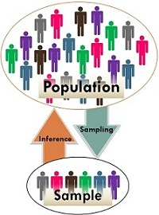

**População**: todos os elementos ou resultados de um problema que está sendo estudado.

**Amostra:** qualquer subconjunto da população que contém os elementos que podem ser observados e é onde as quantidades de interesse podem ser medidas.

## Inferência Estatística

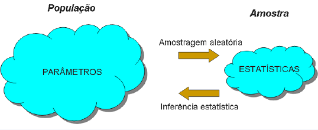

**Variável Aleatória**: Característica numérica do resultado de um experimento.

**Parâmetros**: Característica numérica (desconhecida) da distribuição dos elementos da população.

**Estimador/Estatística**: Função da amostra, construída com a finalidade de representar, ou estimar um parâmetro de interesse na população.

**Estimativa**: Valor numérico que um estimador assume para uma dada amostra.

**Erro amostral:** é a diferença entre um estimador e o parâmetro que se quer estimar.

## Inferência Estatística

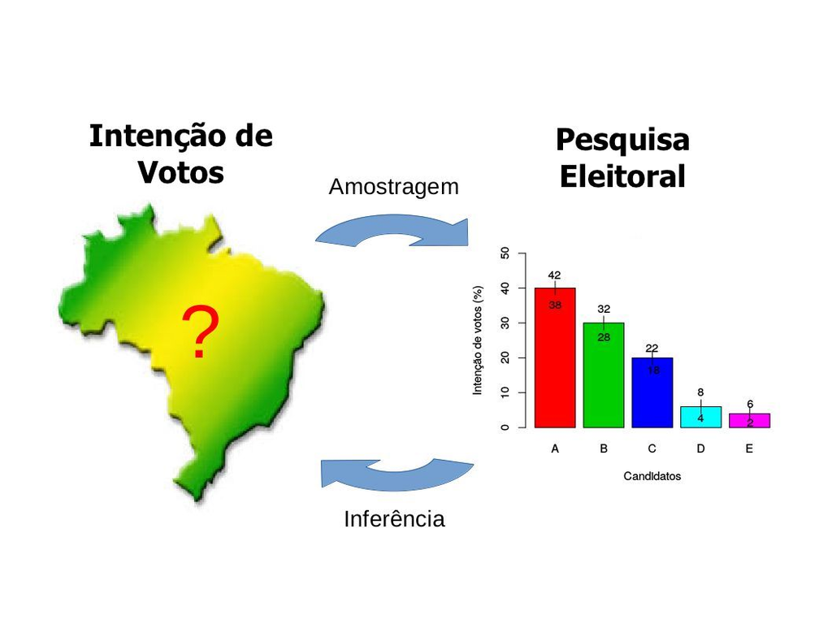

## Estatística

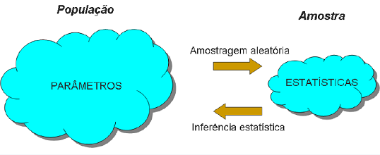

> Seja \(X_{1},...,X_{n}\) uma amostra e \[T = f(X_{1}, \ldots, X_{n})\] é uma estatística.

**Exemplos:**

- \(\bar X_{n}=\frac{1}{n}\sum_{i=1}^{n}X_{i}=\frac{1}{n}(X_{1}+...+X_{n})\)
- \(X_{(1)}=min\{X_{1},...,X_{n}\}\) ou \(X_{(n)}=max\{X_{1},...,X_{n}\}\)
- \(X_{(i)}\) é o i-ésimo valor da amostra ordenada

> Note que uma estatística é uma função que em uma determinada amostra assume um valor específico (estimativa).

## Estatística

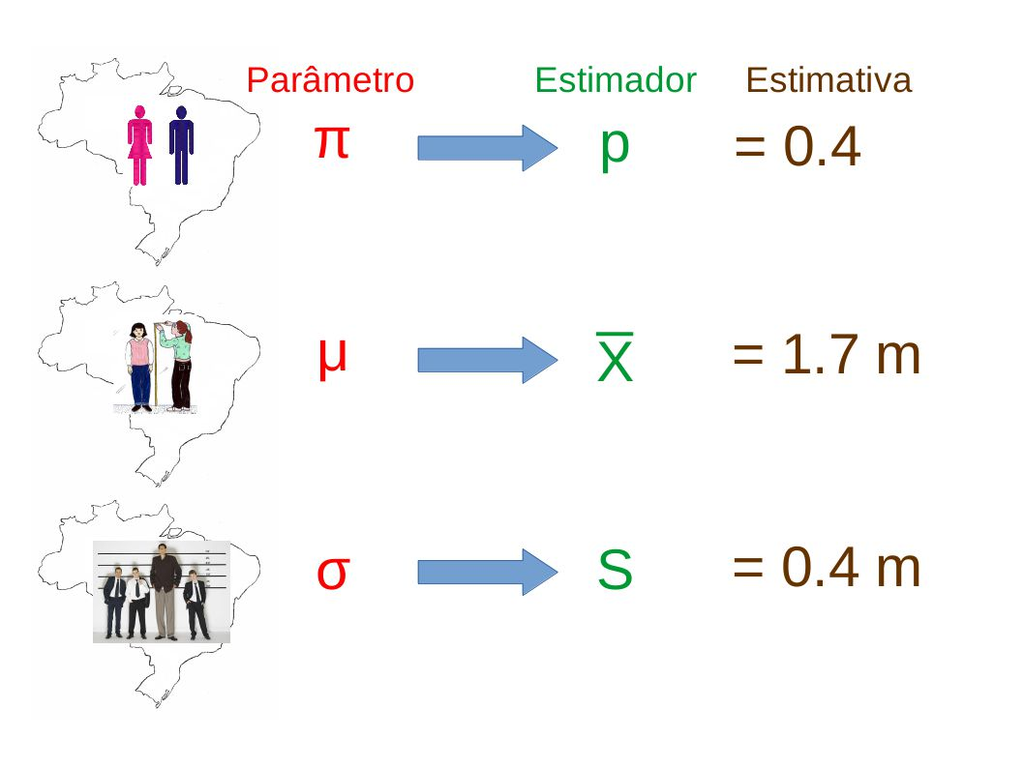

Para que serve uma estatística?

Para "estimar" características de uma população.

> **População:**
- Média \(\mu\)
- Variância \(\sigma^2\)

> **Amostra:**
- Média Amostral \(\bar X = \frac{1}{n} \sum_{i=1}^{n} X_i\)
- Variância Amostral \(S^2 = \frac{1}{n} \sum_{i=1}^n(X_i - \bar X)^2\)

## Exemplo

Temos interesse em conhecer a média e variância das alturas dos brasileiros adultos. Sabemos que a distribuição das alturas pode ser representada por um modelo normal.

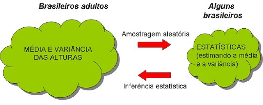

> **Solução 1:** Medir a altura de todos os brasileiros adultos (censo).

> **Solução 2:** Selecionar de forma aleatória algumas pessoas (amostra), analisá-las e inferir propriedades para toda a população.

## Exemplo

Seja \(\theta\) a proporção de alunos na Unicamp que concorda com a presença da PM no campus.

- Inviável perguntar para todos os estudantes: coleta-se uma amostra.
- Planejamento amostral: obter uma amostra aleatória simples de tamanho \(n=100\) alunos, sem reposição.
- Cada \(X_{i}\), \(i=1,...,100\), vai assumir o valor 1 se o aluno \(i\) concorda com presença da PM, e 0 se não.
- Estatística: \(T = \frac{X_{1} + \ldots + X_{100}}{100}\) (proporção amostral)
- Uma vez que a coleta foi implementada, \(T\) assume um valor, por exemplo, 0.63, que será usado para estimar \(\theta\), ou seja, \(\widehat \theta = 0.63\).

## Parâmetro

- Cada quantidade de interesse (como \(\theta\) no exemplo anterior) é chamada de parâmetro da população.
- Para apresentar uma estimativa de um parâmetro (\(\widehat \theta\)), devemos escolher uma estatística (\(T\)).
- Note que da maneira que o plano amostral foi executado (amostra aleatória simples), a estatística \(T\) é uma variável aleatória, visto que cada vez que executarmos o plano amostral poderemos obter resultados diversos.
- Portanto, a estatística \(T\) possui uma distribuição de probabilidade, chamada de **distribuição amostral** de T.

## Distribuição Amostral

## Exemplo

Imagine um fenômeno de interesse que possa ser representado por uma v.a. \(X\) que assume os valores \(1\) ou \(2\) com igual probabilidade.

Nesse caso,

\(\begin{aligned} \mu = \mathbb E(X) &= 1 \times P(X=1) + 2 \times P(X=2) \\ &= 1\times \frac{1}{2} + 2\times \frac{1}{2} = \frac{3}{2} \end{aligned}\)

\(\begin{aligned} \sigma^2 &= Var(X) = \mathbb E[(X - \mu)^2] \\ &= (1-1.5)^2 \times P(X=1) + (2 - 1.5)^2 \times P(X=2) \\ &= \frac{1}{4} \end{aligned}\)

## Exemplo

Imagine que uma população de interesse tenha distribuição como a de \(X\) definida anteriormente.

> Imagine também que, embora saibamos que os valores possíveis sejam \(1\) e \(2\), não tenhamos conhecimento sobre suas respectivas probabilidades.

> Isto é, se temos \(N\) elementos nessa população, podemos pensar que a característica de interesse de cada elemento \(i\) segue uma v.a. \(X_i\) em que \(P(X_i=1)=P(X_i=2)=1/2\), mas nós não sabemos disso.

> Imagine que o interesse seja \(\mu\).

## Exemplo

Vamos coletar uma amostra aleatória simples com reposição (\(AAS_c\)) de tamanho \(n=2\) e calcular a média amostral.

> Usaremos esta média amostral para estimar \(\mu\).

> Quão útil é esta estimativa que se baseia em apenas 2 elementos da população?

> Quão precisa?

## Exemplo

> Imagine que o aluno \(A\) coleta uma \(AAS_c\) com \(n=2\) a partir da população, obtém os dados e calcula \(\bar X\).

> O aluno \(B\) coleta uma \(AAS_c\) com \(n=2\) a partir da população, obtém os dados e calcula \(\bar X\).

> As duas médias amostrais serão necessariamente iguais?

> A média amostral é uma v.a. e, portanto, tem uma distribuição de probabilidade.

## Exemplo

> Todas as combinações possíveis de valores para o primeiro e para o segundo elemento amostrados segundo o plano \(AAS_c\) com \(n=2\) são:

| Possibilidades | \((X_1 = 1, X_2 = 1)\) | \((X_1 = 1, X_2 = 2)\) | \((X_1 = 2, X_2 = 1)\) | \((X_1=2,X_2=2)\) |
| --- | --- | --- | --- | --- |
| \(\bar X\) | 1 | 1.5 | 1.5 | 2 |
| \(P(X_1 = i, X_2 = j)\) | 0.25 | 0.25 | 0.25 | 0.25 |

> \(\displaystyle \mathbb E(\bar X) = 1 \times \frac{1}{4} + 1.5 \times \frac{1}{2} + 2 \times \frac{1}{4} = \frac{3}{2} = 1.5\)

> \(\begin{aligned} Var(\bar X) &= \mathbb E[(\bar X - \mathbb E(\bar X))^2 ] \\ &= (1 - 1.5)^2 \times \frac{1}{4} + (1.5 - 1.5)^2 \frac{1}{2} + (2 - 1.5)^2 \frac{1}{4} = \frac{1}{8} \end{aligned}\)

> Note que: \(\displaystyle \mathbb E(\bar X) = \mu = \mathbb E(X)\) e \(\displaystyle Var(\bar X) = \frac{\sigma^2}{n} = \frac{Var(X)}{n}\).

## Exemplo

Distribuição de probabilidade de \(X\) (esquerda) e de \(\bar X\) (direita):

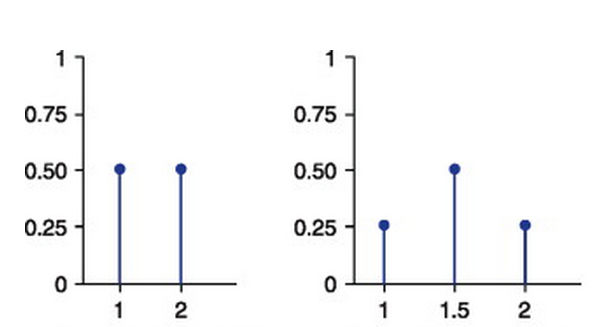

## Distribuição Amostral

**Resultado:** Seja \(X\) uma v.a. com média \(\mu\) e variância \(\sigma^{2}\) e \(X_{1}, \ldots, X_{n}\) uma amostra aleatória simples de \(X\). A média amostral \[\bar X_n = \frac{X_1 + \ldots + X_n}{n}\] tem as seguintes propriedades:

> \[\mathbb E (\bar X_n) = \mu \qquad \mbox{e} \qquad Var(\bar X_n) = \frac{\sigma^2}{n}.\]

Ou seja, embora \(\mu\) seja desconhecido, sabemos que o valor esperado da média amostral é \(\mu\).

Além disso, conforme o tamanho amostral aumenta, a imprecisão da média amostral para estimar \(\mu\) fica cada vez menor, pois \(Var(\bar X) = \sigma^2/n\).

## Exemplo

> **Exemplo:** \(X_1, X_2, X_3\) ensaios de Bernoulli(p) independentes.
- \(\mu = \mathbb E(X_i) = 0.3 \qquad \Rightarrow \qquad \mathbb E (\bar X_3) = 0.3.\)
- \(\sigma^2 = Var(X_i) = p(1 - p) = 0.3(0.7) = 0.21 \;\; \Rightarrow \;\; Var(\bar X_3) = \frac{0.21}{3} = 0.07\)

## Teorema do Limite Central

## Teorema do Limite Central

Usando o resultado enunciado anteriormente, temos a esperança e a variância da média amostral \(\bar X\): \(\mathbb E(\bar X) = \mu\) e \(Var(\bar X) = \frac{\sigma^2}{n}\).

> No entanto, para conhecermos a distribuição de probabilidade de \(\bar X\), como foi feito no exemplo anterior, é preciso conhecer todos os valores possíveis de \(X\) e suas respectivas probabilidades.

> Mas, se conhecermos tudo isso, não precisamos fazer amostragem nem inferência: saberemos tudo o que desejarmos daquela população!

> O exemplo anterior foi um caso hipotético apenas para demonstrar como a média amostral \(\bar X\) se comporta quando realizamos a amostragem.

> Na prática, não teremos informações suficientes para de fato descrevermos a distribuição exata de \(\bar X\).

## Teorema Central do Limite (TLC)

**Resultado**

Para uma amostra aleatória simples \(X_1, \ldots ,X_n\) coletada de uma população com média \(\mu\) e variância \(\sigma^{2}\), a distribuição amostral de \(\bar X_{n}\) aproxima-se de uma **distribuição Normal** de média \(\mu\) e variância \(\frac{\sigma^{2}}{n}\), quando \(n\) for suficientemente grande.

Definimos também:

\[Z = \frac{\bar X_{n} - \mu}{\sigma / \sqrt{n}} \sim N(0,1)\]

## Teorema do Limite Central

## Exemplo

Seja \(X_{1}, \ldots ,X_{n}\) uma amostra aleatória de tamanho \(n\) tal que \(X \sim Exp(2)\): \[f_{X_i}(x) = 2e^{-2x}, \qquad \mbox{para } x \geq 0\]

Então \(\mathbb E(X_i) = \frac{1}{2}\) e \(Var(X_i) = \frac{1}{4}\).

Suponha que \(X_{i}\) modela o tempo de vida de um transistor em horas. Os tempos de vida de 100 transistores são coletados. Desejamos estudar a variável aleatória \(\bar X_{100}\) (média amostral de uma amostra de tamanho 100). Sabemos: \[\mathbb E(\bar X_{100}) = \frac{1}{2} \qquad \mbox{e} \qquad Var(\bar X_{100}) = \frac{1/4}{100} = \frac{1}{400}.\]

Pelo TLC, temos que: \(\displaystyle \bar X_{n}\sim N \left(\frac{1}{2},\frac{1}{400}\right)\)

## Exemplo

\(\begin{aligned} F_{\bar X_{100}}(x) = P\left(\bar X_{100} \leq x\right) & = P\left(\frac{\bar X_{100}-(1/2)}{(1/2)/\sqrt{100}} \leq \frac{x-(1/2)}{(1/2)/\sqrt{100}}\right) \\ & = P\left(Z \leq 10(2x-1) \right) \end{aligned}\)

e

\(\begin{aligned} P\left(\bar X_{100} \geq x\right) & = 1 - P\left(\bar X_{100} < x\right) \\ & = 1 - P\left(\frac{\bar X_{100}-(1/2)}{(1/2)/\sqrt{100}} \leq \frac{x-(1/2)}{(1/2)/\sqrt{100}}\right) \\ & = 1 - P\left(Z \leq 10(2x-1) \right) \end{aligned}\)

## Exemplo

\(X=\) resultado obtido no lançamento de um dado honesto.

| \(x\) | 1 | 2 | 3 | 4 | 5 | 6 |
| --- | --- | --- | --- | --- | --- | --- |
| \(p(x)=P(X=x)\) | \(\frac{1}{6}\) | \(\frac{1}{6}\) | \(\frac{1}{6}\) | \(\frac{1}{6}\) | \(\frac{1}{6}\) | \(\frac{1}{6}\) |

> \(\mathbb E(X) = \frac{1}{6}\times(1+2+3+4+5+6) = \frac{21}{6} = 3.5\)

## Exemplo

> O primeiro histograma a seguir mostra o resultado de 10000 repetições do seguinte experimento: observar o resultado do lançamento de 1 dado. Repare que é muito próximo de uma distribuição uniforme discreta (chance 1/6 para cada resultado).

> O segundo histograma mostra o resultado de 10000 repetições do seguinte experimento: observar a média do lançamento de 2 dados (equivalente a observar a média de 2 lançamentos de um dado).

> O último histograma mostra o resultado de 10000 repetições do seguinte experimento: observar a média do lançamento de 100 dados (equivalente a observar a média de 100 lançamentos de um dado).

## Exemplo

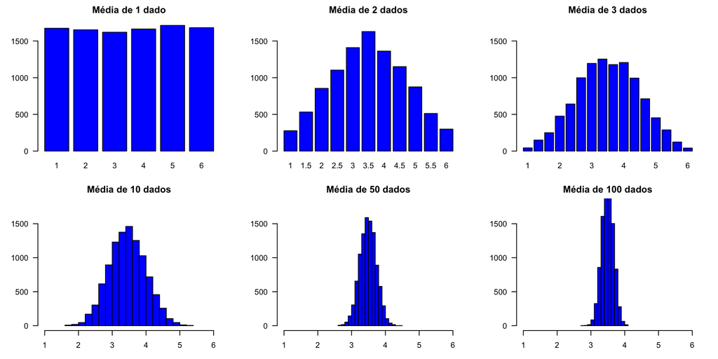

## Teorema do Limite Central (TLC)

Você pode verificar o comportamento de \(\bar X\) para várias distribuições de \(X\):

https://nishantsbi.shinyapps.io/CLT_Shiny

https://gallery.shinyapps.io/CLT_mean/

## Aproximação da Distribuição Binomial pela Normal

## Aproximação da Binomial pela Normal

> Consideremos uma população em que a proporção de indivíduos portadores de uma certa característica seja \(p\). \[ X_{i} = \left\{ \begin{array}{ll} 1, & \mbox{se o indivíduo i possui a característica} \\ 0, & \mbox{caso contrário} \\ \end{array} \right.\]

> Veja que \(X_{i}\sim Bernoulli(p)\); \(i = 1, 2, \ldots, n\).

> Se as observações são independentes: \(S_{n} = X_{1} + \ldots + X_{n} \sim Bin(n,p)\).

> Após a coleta de uma amostra aleatória simples de \(n\) indivíduos, podemos considerar que um estimador de \(p\) é dado por:

> \[\widehat{p} = \frac{S_{n}}{n} \quad \mbox{(média amostral)}.\]

## Aproximação da Binomial pela Normal

Utilizando a distribuição exata (n pequeno): \[P\left(\widehat p = \frac{k}{n}\right) = P\left(\frac{S_{n}}{n} = \frac{k}{n}\right) = P\left(S_{n} = k\right) = {n \choose k} p^{k} \left(1-p\right)^{n-k},\]  
para \(k=0,1,...,n\).

> Utilizando a aproximação para a Normal (n grande): \[\widehat p \sim N\left(p, \frac{p(1-p)}{n} \right)\]

## Exemplo

Se \(p\) for a proporção de fumantes no estado de SP (\(p=0.2\)) e tivermos coletado uma amostra aleatória simples de 500 indivíduos: \[ X_{i} = \left\{ \begin{array}{ll} 1, & \mbox{se o indivíduo i é fumante} \\ 0, & \mbox{caso contrário} \\ \end{array} \right.\]

Qual a probabilidade de que termos observado não mais que 25% de fumantes na amostra?

> O estimador de \(p\) é: \(\widehat p = \frac{1}{500} \sum_{i=1}^{500} X_i\).

> Pela aproximação Normal, \(\widehat p \sim N\left(0.2, \frac{0.2\times0.8}{500}\right) = N \left(0.2, 0.00032 \right)\)

> \[P\left( \widehat p \leq 0.25 \right) = P \left(Z\leq 2.795 \right) = \Phi\left(2.795 \right) = 0.9974\]

## Aproximação da Binomial pela Normal

> Se \(\quad \widehat p = \frac{S_n}{n} \quad \Longrightarrow \quad S_n = n\widehat p\).

> Quando \(n\) é grande o suficiente: \(\quad \widehat p \sim N \left(p, \frac{p(1-p)}{n}\right)\)

> Nesse caso, qual a distribuição de \(S_n\)?

> Vimos que \(S_n = X_1 + \ldots + X_n \sim Bin(n, p)\)

> Pelas propriedades da distribuição Normal: \[S_n = n \widehat p \sim N \left(np, np(1-p) \right)\]

> Portanto, quando \(n\) é grande, \(Bin(n, p) \approx N \left(np, np(1-p) \right)\)

## Exemplo

Seja \(X \sim Bin(100, 0.4)\).

Qual a probabilidade de \(X\) ser menor ou igual a \(50\)?

Sabemos que:

- \(\mathbb E(X) = 100 \times0.4 = 40\)
- \(Var(X) = 100 \times 0.4 \times0.6 = 24\)

Como \(n\) é grande, podemos usar a aproximação \(X \approx N(40,24)\). Portanto,

\[P\left( X \leq 50 \right) = P\left(Z \leq \frac{50-40}{\sqrt{24}}\right) \approx \Phi \left( \frac{10}{\sqrt{24}} \right) = \Phi \left(2.04 \right) \approx 0.9793\]

## Leituras

- Devore: capítulo 5.
- [Ross](http://www.sciencedirect.com/science/article/pii/B9780123743886000077): capítulo 7.
- [OpenIntro](https://www.openintro.org/stat/textbook.php): seção 4.1.
- Magalhães: capítulo 7.

Slides produzidos pelos professores:

- Samara Kiihl
- Tatiana Benaglia
- Benilton Carvalho